# MOFA2: training a model in R

Ricard Argelaguet

European Bioinformatics Institute, Cambridge, UK

ricard@ebi.ac.uk

2020-05-07

# 1 Load libraries

```r
library(data.table)
library(MOFA2)
```

This vignette contains a detailed tutorial on how to train a MOFA model using R. A concise template script can be found [here](https://github.com/bioFAM/MOFA2/blob/master/template_script.R)

# 2 What is MOFA?

MOFA is an **unsupervised statistical framework for the integration of multi-omic data sets**.  
Intuitively, MOFA can be viewed as a versatile and statistically rigorous generalization of principal component analysis (PCA) to multi-omics data. Given several data matrices with measurements of multiple -omics data types on the same or on overlapping sets of samples, MOFA infers an **interpretable low-dimensional representation in terms of a few latent factors** that (hopefully) captures the relevant signal in the input data.  
Effectively MOFA disentangles the sources of variation in the data, identifying the factors that are shared across multiple data modalities from the factors that drive variability in a single data modality.

## 2.1 Is MOFA appropriate for my data?

MOFA (and factor analysis models in general) are useful to uncover variation in complex data sets that are expected to contain multiple sources of heterogeneity. This requires a relatively large sample size (at least ~15 samples). In addition, MOFA needs the multi-modal measurements to be derived from the same samples. It is fine if you have samples that are missing some data modality, but there has to be a significant degree of matched measurements.

# 3 Load data

To create a MOFA object you need to specify four dimensions: samples, features, view(s) and group(s). MOFA objects can be created from a wide range of input formats, including:

- **a list of matrices**: this is recommended for relatively simple data.
- **a long data.frame**: this is recommended for complex data sets with multiple views and/or groups.
- **MultiAssayExperiment**: to connect with Bioconductor objects.
- **Seurat**: only for single-cell genomics users.

## 3.1 List of matrices

A list of matrices, where each entry corresponds to one view. Samples are stored in columns and features in rows.

Let’s simulate some data to start with

```r
data <- make_example_data(
  n_views = 2,
  n_samples = 200,
  n_features = 1000,
  n_factors = 10
)[[1]]

lapply(data,dim)
```

```
## $view_1
## [1] 1000  200
##
## $view_2
## [1] 1000  200
```

Create the MOFA object:

```r
MOFAobject <- create_mofa(data)
```

In case you are using the multi-group functionality, the groups can be specified using a vector with the group ID for each sample.

Please keep in mind that this is a rather advanced option that we disencourage for MOFA beginners. For more details on how the multi-group inference works, read the [FAQ section](https://github.com/bioFAM/MOFA2#2-faq-on-the-multi-group-functionality).

```r
N = ncol(data[[1]])
groups = c(rep("A",N/2), rep("B",N/2))

MOFAobject <- create_mofa(data, groups=groups)
```

```
## You have requested the multi-group inference framework.
## It is an advanced option, if this is the first time that you are running MOFA, we suggest that you try first without specifying groups
```

## 3.2 Long data.frame

A long data.frame with columns `sample`, `feature`, `view`, `group` (optional), `value`.  
In my opinion this is the best format for complex data sets with multiple omics and potentially multiple groups of data. Also, there is no need to add rows that correspond to missing data:

```r
dt = fread("ftp://ftp.ebi.ac.uk/pub/databases/mofa/getting_started/data.txt.gz")
head(dt)
```

```
##              sample   group          feature   view value
## 1: sample_0_group_0 group_0 feature_0_view_0 view_0 -2.05
## 2: sample_1_group_0 group_0 feature_0_view_0 view_0  0.10
## 3: sample_2_group_0 group_0 feature_0_view_0 view_0  1.44
## 4: sample_3_group_0 group_0 feature_0_view_0 view_0 -0.28
## 5: sample_4_group_0 group_0 feature_0_view_0 view_0 -0.88
## 6: sample_5_group_0 group_0 feature_0_view_0 view_0 -1.18
```

```r
# Let's ignore the grouping information to start
dt[,group:=NULL]
```

Create the MOFA object

```r
MOFAobject <- create_mofa(dt)
```

```
## Creating MOFA object from a data.frame...
```

```
## No "group" column found in the data.frame, we will assume a common group for all samples
```

```r
print(MOFAobject)
```

```
## Untrained MOFA model with the following characteristics:
##  Number of views: 2
##  Views names: view_0 view_1
##  Number of features (per view): 1000 1000
##  Number of groups: 1
##  Groups names: single_group
##  Number of samples (per group): 200
```

## 3.3 Visualise the structure of the data

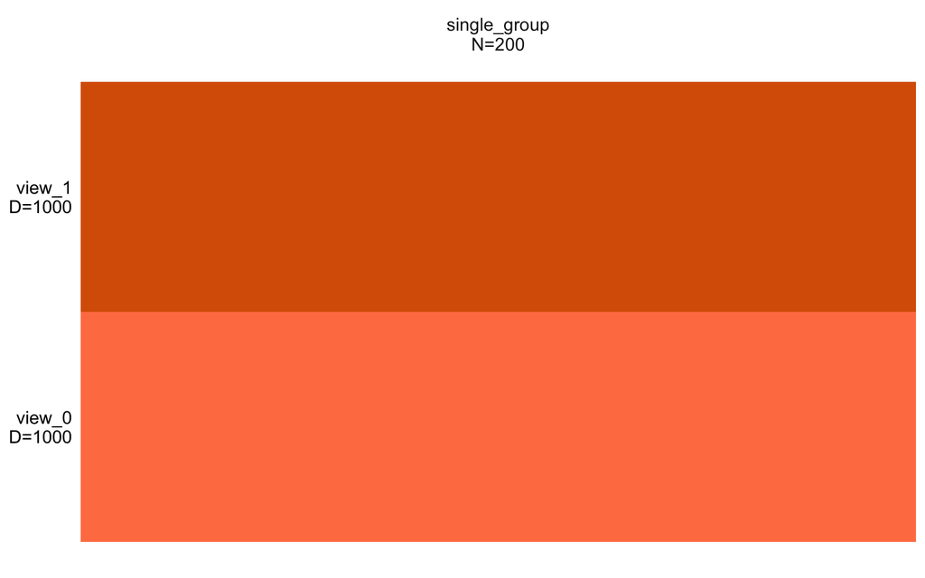

```r
plot_data_overview(MOFAobject)
```

# 4 Define options

## 4.1 Define data options

- **scale_groups**: if groups have different ranges/variances, it is good practice to scale each group to unit variance. Default is `FALSE`
- **scale_views**: if views have different ranges/variances, it is good practice to scale each view to unit variance. Default is `FALSE`

```r
data_opts <- get_default_data_options(MOFAobject)
head(data_opts)
```

```
## $scale_views
## [1] FALSE
##
## $scale_groups
## [1] FALSE
##
## $views
## [1] "view_0" "view_1"
##
## $groups
## [1] "single_group"
```

## 4.2 Define model options

- **num_factors**: number of factors
- **likelihoods**: likelihood per view (options are “gaussian”, “poisson”, “bernoulli”). By default they are learnt automatically. We advise users to use “gaussian” whenever possible!
- **spikeslab_factors**: use spike-slab sparsity prior in the factors? default is `FALSE`.
- **spikeslab_weights**: use spike-slab sparsity prior in the weights? default is `TRUE`.
- **ard_factors**: use ARD prior in the factors? Default is `TRUE` if using multiple groups.
- **ard_weights**: use ARD prior in the weights? Default is `TRUE` if using multiple views.

Only change the default model options if you are familiar with the underlying mathematical model!

```r
model_opts <- get_default_model_options(MOFAobject)
head(model_opts)
```

```
## $likelihoods
##     view_0     view_1
## "gaussian" "gaussian"
##
## $num_factors
## [1] 15
##
## $spikeslab_factors
## [1] FALSE
##
## $spikeslab_weights
## [1] TRUE
##
## $ard_factors
## [1] FALSE
##
## $ard_weights
## [1] TRUE
```

## 4.3 Define train options

- **maxiter**: number of iterations. Default is 1000.
- **convergence_mode**: “fast”, “medium”, “slow”. For exploration, the fast mode is good enough.
- **startELBO**: initial iteration to compute the ELBO (the objective function used to assess convergence).
- **freqELBO**: frequency of computations of the ELBO.
- **gpu_mode**: use GPU mode? (needs [cupy](https://cupy.chainer.org/) installed and a functional GPU).
- **stochastic**: use stochastic inference? (default is `FALSE`).
- **verbose**: verbose mode?
- **seed**: random seed

```r
train_opts <- get_default_training_options(MOFAobject)
head(train_opts)
```

```
## $maxiter
## [1] 1000
##
## $convergence_mode
## [1] "medium"
##
## $drop_factor_threshold
## [1] -1
##
## $verbose
## [1] FALSE
##
## $startELBO
## [1] 1
##
## $freqELBO
## [1] 1
```

# 5 Build and train the MOFA object

Prepare the MOFA object

```r
MOFAobject <- prepare_mofa(
  object = MOFAobject,
  data_options = data_opts,
  model_options = model_opts,
  training_options = train_opts
)
```

Train the MOFA model

```r
outfile = paste0(getwd(),"/model.hdf5")
MOFAobject.trained <- run_mofa(MOFAobject, outfile)
```

If everything is successful, you should observe an output analogous to the following:

```
######################################
## Training the model with seed 1 ##
######################################

Iteration 1: time=0.03, ELBO=-52650.68, deltaELBO=837116.802 (94.082647669%), Factors=10

(...)

Iteration 9: time=0.04, ELBO=-50114.43, deltaELBO=23.907 (0.002686924%), Factors=10

#######################
## Training finished ##
#######################

Saving model in /Users/ricard/data/mofa2/hdf5/model.hdf5...
```

# 6 Downstream analysis

This finishes the tutorial on how to train a MOFA object from R. To continue with the downstream analysis, follow [this tutorial](https://raw.githack.com/bioFAM/MOFA2/master/MOFA2/vignettes/downstream_analysis.html)